# Proyecto final de visualizacion

Manuel Emilio Arias

2025-10-25

```r
#Proyecto Final Visualizacion

library(ggplot2)
library(dplyr)
Conejillos = ToothGrowth
```

Describir brevemente el contexto del conjunto de datos: ¿qué representa?, ¿cuántas observaciones y variables tiene?, ¿qué tipo de variables hay?

Explicar la finalidad del análisis: ¿qué decisiones podría informar este análisis?

```r
#En cuanto al contexto del conjunto de datos, ToothGrowth registra la longitud de los dientes de 60 conejillos de indias que recibieron vitamina C mediante dos metodos (suplementos) distintos, VC (ácido ascórbico) y OJ (jugo de naranja), en tres dosis diferentes de 0.5, 1 y 2 mg.

#Este analisis podria ser clave para determinar la manera en que afecta el tipo de suplemento y dosis a utilizar en el crecimiento dental de estos animales. Como que dosis produce el mayor crecimiento dental o recomendaciones biologicas de la eficacia de la vitamina C en distintas formas.
```

2. Incluir al menos 3 tipos de visualización diferentes, usando herramientas como ggplot2 o base R:

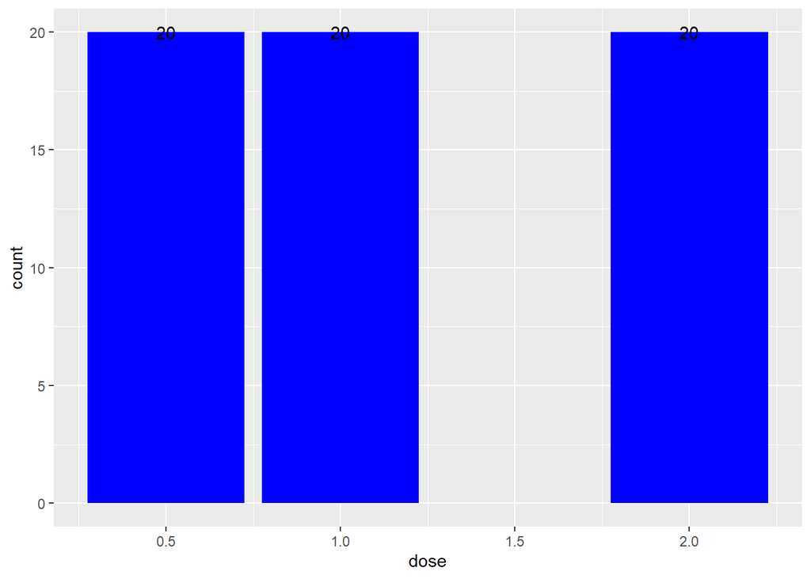

```r
#Una de cantidades (barras, columnas, líneas)
#Grafico de barras
ggplot( Conejillos, aes( x=dose )) + geom_bar( fill= "blue") + geom_text(stat= "count", aes(label = ..count..))
```

Este grafico de barras nos muestra a cuantos ejemplares de conejillos de indias se le suministro determinada dosis, y como se puede ver en la visualizacion, las dosis fueron repartidas de manera equitativa, lo que de por si no aporta mucho al analisis, pero es un grafico necesario puestro que le base de datos tiene variables bastante limitadas.

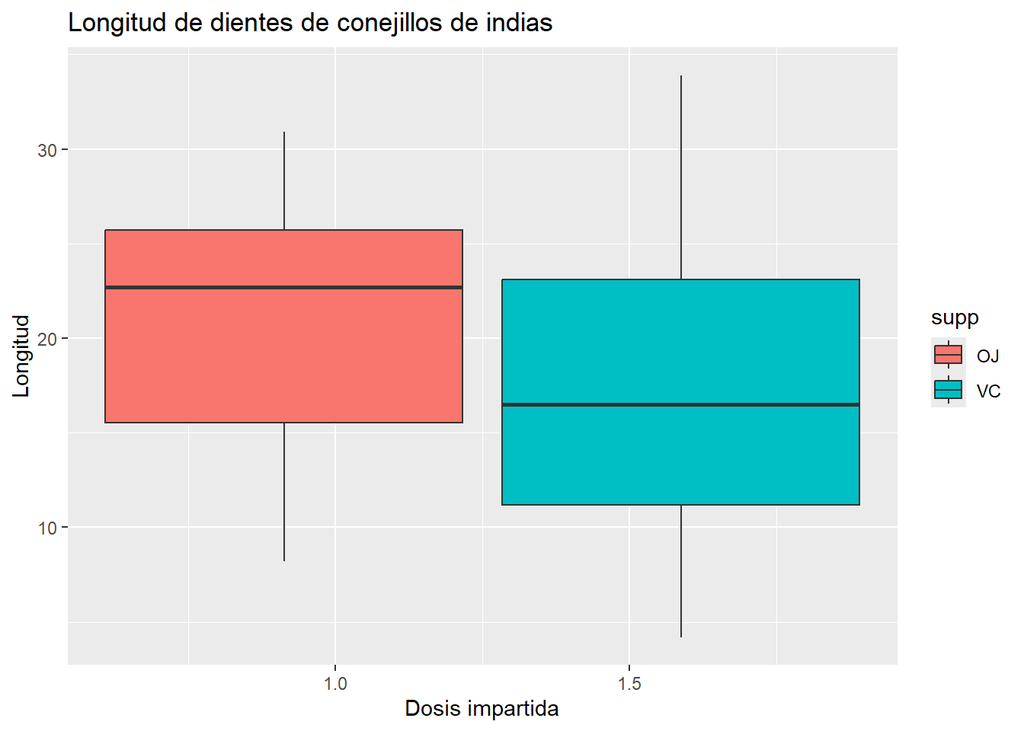

```r
#Una de distribución (histograma, boxplot, densidad)
#boxplot
ggplot(Conejillos, aes(x= dose , y= len, fill= supp)) + geom_boxplot()+ labs(title= "Longitud de dientes de conejillos de indias", y= "Longitud", x="Dosis impartida")
```

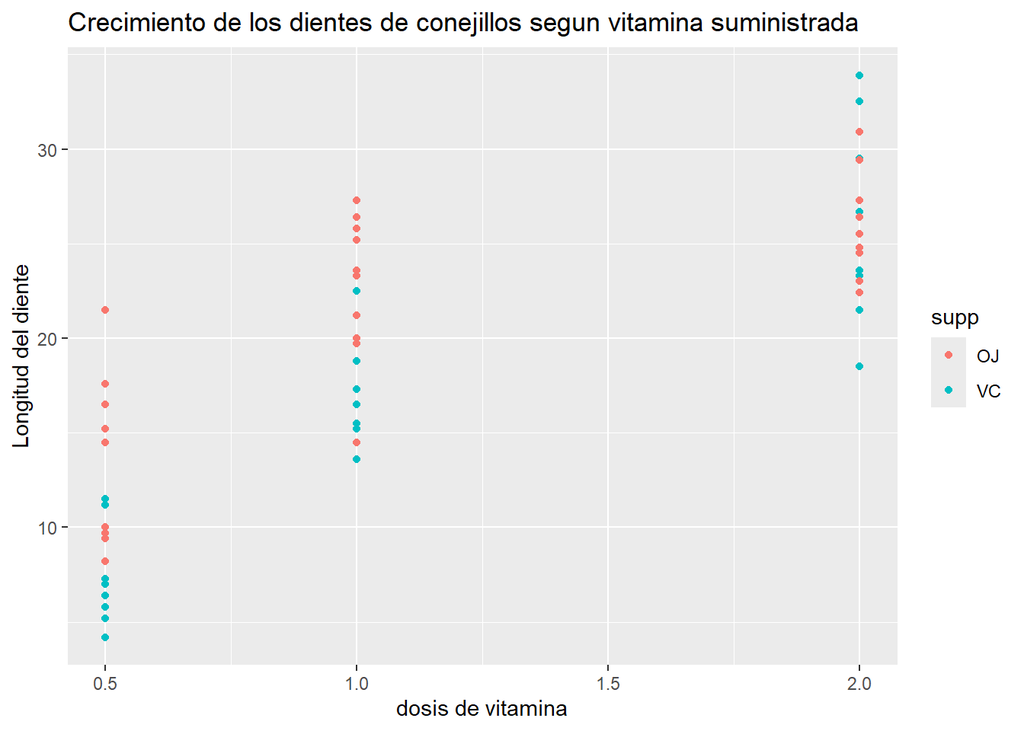

```r
#Una de relaciones entre variables (scatterplot o gráfico de burbujas)
#grafico de puntos
ggplot(Conejillos, aes(x=dose, y=len, color= supp)) + geom_point() + labs(
title = "Crecimiento de los dientes de conejillos segun vitamina suministrada",
x= "dosis de vitamina",
y= "Longitud del diente")
```

En este grafico de puntos, se muestra el crecimiento de los dientes de los conejillos en funcion a la dosis suministrada, pudiendo observar a simple vista que generalmente a mayor dosis, mayor es el crecimiento, tambien subdivide el tipo de suplemento por color para mejor interpretacion.